# Pollen time series plot

INFO 550 HW2

Wenhao Wang

2021-09-22

### Introduction

This script helps to creat a time-series plot on the pollen sense measured total pollen count in particular device (87081 in this script). The script first clean the data selecting valid measurement. Before applied the code in this script, please make sure to storage the original raw pollen data in the working directory. In the sample script, the working directory was set as ‘/Users/wenhao/Desktop/INFO550/HW2/’. You need following packages to run this code: **ggplot2**,**dplyr**,**stringr**

### Data preparation

##### Set working directory:

```r
dir <- paste('/Users/wenhao/Desktop/INFO550/HW2/')
setwd(dir)
```

##### Load the pollen sense raw measurement data:

```r
RAW.87081 <- read.csv('PS_Pollen_2020_1device_87081.csv')
```

##### Clean the dataset by following rules:

```r
RAW.87081.clean <- RAW.87081[RAW.87081$Probability>0.8,]
daily.87081 <- group_by(RAW.87081.clean,Day) %>% summarise (.,Count=n())
```

#### Creat a time-series plot on the daily pollen count

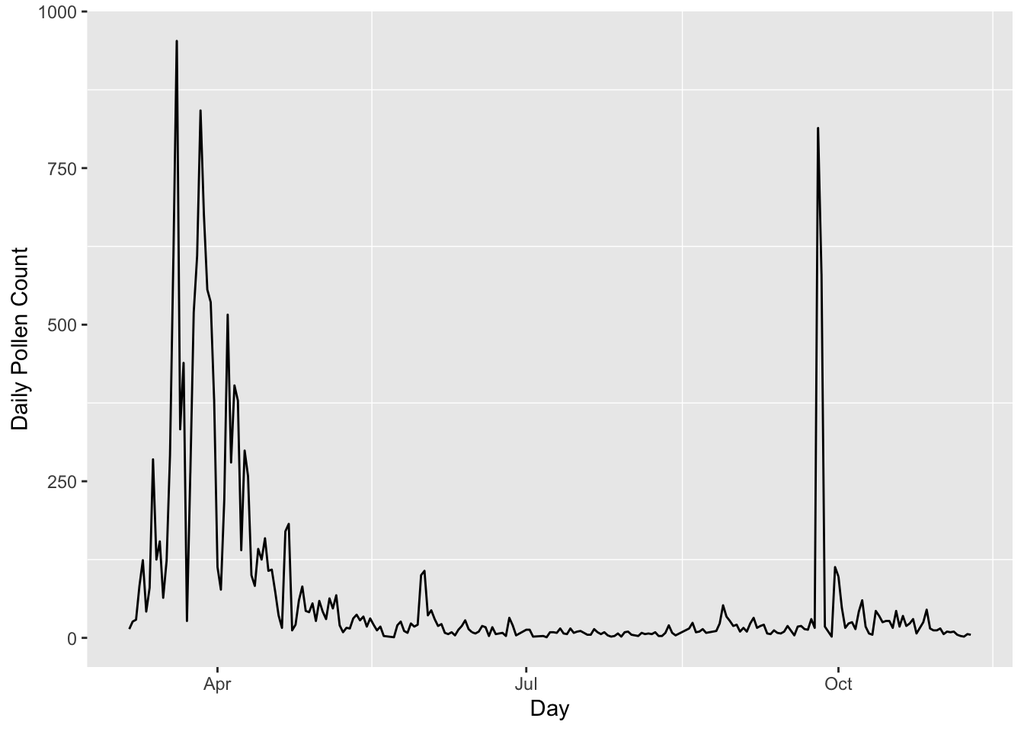

```r
daily.87081$Day <- as.Date(daily.87081$Day)
p <- ggplot(data=daily.87081,aes(x=Day,y=Count))+geom_line()
p + ylab("Daily Pollen Count") + theme_set(theme_bw()) + theme(panel.grid.major=element_line(colour=NA))
```

We measured the peak of pollen count during the spring season, while we observe highest value of 953 on 2020-03-20. There is also a peak pollen count of 814 during September, while the highest day lay on 2020-09-25.